# Homework-09

Author

L. Harvey

## Homework 09 (Revised 03/20)

Homework 09 marks the end of an era!

### Exercise 9.1.1: Loading the GSS 2022 Data

Load the GSS dataset for 2022 and choose one outcome variable and one “treatment” variable. They can be any two variables you want and the treatment can be either binary or continuous.

```r
# Background Code

library(gssr)
library(tidyverse)
library(marginaleffects)
library(broom)
library(WeightIt)
library(MatchIt)
library(cobalt)
gss2022 <- gss_get_yr(2022)
```

```
Fetching: https://gss.norc.org/documents/stata/2022_stata.zip
```

**Research Question:** Is there a causal relationship between having a college degree (treatment variable) and supporting affirmative action (outcome variable)?

**My Hypothesis:** College-educated folks will demonstrate more support for affirmative action than folks without a college degree.

```r
d <- gss2022 |>
  select(degree, affrmact) |>
  haven::zap_labels() |>
  haven::zap_missing() |>
  mutate(bachelors_plus = if_else(degree >= 3, 1L, 0L),
         degree = if_else(degree >= 3, "BA or More", "No BA"),
         supports = if_else(affrmact <= 2, 1L, 0L),
         affrmact = if_else(supports <= 2, "Supports AA", "Opposes AA")) |>
  drop_na() |>
  select(bachelors_plus, supports, degree, affrmact)
```

Wherein the variables are recoded as follows:

`bachelors_plus` (formerly `degree`):

- 1 = Respondent has at least a Bachelor’s degree (i.e., BA or more)
- 0 = Respondent has less than a Bachelor’s degree (i.e., junior college or less)

`affirmative` (formerly `affrmact`):

- 1 = Respondent supports affirmative action (i.e., “Strongly Favors,” “Not Strongly Favors”)
- 0 = Respondent opposes affirmative action (i.e., “Not Strongly Opposes,” “Strongly Opposes”)

What is the “naive” estimate for the effect of $T$ on $Y$ ?

To find the naive estimate, we have to find the expected value for $Y^0$ and $Y^1$.

```r
table1 <- table(supports = d$supports, bachelors_plus = d$bachelors_plus)
addmargins(table1)
```

```
        bachelors_plus
supports    0    1  Sum
     0   1052  534 1586
     1    391  252  643
     Sum 1443  786 2229
```

```r
naive_estimate <- lm(supports ~ bachelors_plus, data = d)
tidy(naive_estimate)
```

```
# A tibble: 2 × 5
  term           estimate std.error statistic   p.value
  <chr>             <dbl>     <dbl>     <dbl>     <dbl>
1 (Intercept)      0.271     0.0119     22.7  4.11e-103
2 bachelors_plus   0.0496    0.0201      2.47 1.34e-  2
```

### Exercise 9.1.2: Some Theory

Think very hard about the list of possible confounding variables that might affect this estimate.

Part One: Draw a DAG.

[figure not shown]

Part Two: What is your estimand (ATE, ATT, and ATU)?

For this research question, I’m focused on the ATT, because I want to explore the causal impact that completion of a college degree has on supportive attitudes towards others completing the same. I am interested in evaluating the group of individuals who were *already likely to get a college degree*, because I anticipate a) that they are qualitatively different than individuals who were unlikely to get a college degree, and that b) because of this dissimilarity between groups, there would be a difference in supportive attitudes towards affirmative action policies.

### Exercise 9.1.3: Selecting Covariates

Select the appropriate covariates in the GSS that allow for causal identification. Be careful when selecting these variables and make a note for any transformation you decide is adequate (i.e., coding a covariate to be binary).

From the DAG above, `degree`, `affrmact`, `polviews`, `padeg`, `madeg`, and `class` are all variables that will be adjusted in the code below.

```r
e <- gss2022 |>
  select(degree, affrmact, age, polviews, padeg, madeg, class, major1, race) |>
  haven::zap_labels() |>
  haven::zap_missing() |>
  mutate(bachelors_plus = if_else(degree >= 3, 1L, 0L),
         supports = if_else(affrmact <= 2, 1L, 0L),
         conservative = if_else(polviews >= 4, 1L, 0L),
         educated_parents = pmax(padeg, madeg, na.rm = TRUE),
         low_ses = if_else(class <= 2, 1L, 0L),
         high_ses = if_else(class >= 3, 1L, 0L),
         black = if_else(race == 2, 1L, 0L)) |>
  drop_na() |>
  ## dropped major1 because didn't know how to recode it
  select(bachelors_plus, degree, supports, affrmact, conservative, polviews, educated_parents,
         madeg, padeg, low_ses, high_ses, class, age, race, black)
```

The variables in dataframe `e` are recoded as follows:

`bachelors_plus` (formerly `degree`):

- 1 = Respondent has at least a Bachelor’s degree (i.e., BA or more)
- 0 = Respondent has less than a Bachelor’s degree (i.e., junior college or less)

`affirmative` (formerly `affrmact`):

- 1 = Respondent supports affirmative action (i.e., “Strongly Favors,” “Not Strongly Favors”)
- 0 = Respondent opposes affirmative action (i.e., “Not Strongly Opposes,” “Strongly Opposes”)

`conservative` (formerly `polviews`):

- 1 = Respondent is conservative (i.e., “Moderate,” “Slightly Conservative,” “Conservative,” “Extremely Conservative”)
- 0 = Respondent is not conservative (i.e., “Extremely Liberal,” “Liberal,” “Slightly Liberal”)

`educated_parents` (formerly `padeg` and `madeg`) now takes the maximum value of “education” between both columns (therefore accounting for respondents raised by a single parent)

`low_ses` (formerly `class`):

- 1 = Respondent has low SES (i.e., “Lower Class” and “Working Class”)
- 0 = Respondent does not have low SES

`high_ses` (formerly `class`):

- 1 = Respondent has high SES (i.e., “Middle Class” and “Upper Class”)
- 0 = Respondent does not have high SES
- Please note: I realized that I actually coded `high_ses` and `low_ses` to be collinear, which was screwing up my regression. Thus, I removed `high_ses` from the regression model.

Are there any variables missing from the DAG you drew earlier?

The DAG was modified throughout this homework assignment to account for any variables that were missing (e.g., I originally did not include `class` on the DAG, then later realized it was an important variable that could feasibly impact `polviews`, etc.). The `educ` variable was originally included, but was later cut from the DAG. This is because both `educ` and `degree` contain the same information, and I had concerns that inclusion of both variables may “break” the regression model I wanted to create.

Note also that there is no direct causal relationship identified between `race` and `bachelors degree`. This is because assumptions made in the DAG assert that there is not a causal relationship between one’s race and obtaining a degree (i.e., being white does not *cause* one to get a degree, but it is a contributing factor in terms of whites having greater accessibility to structural advantages necessary to enter universities). As it would be remiss to act as though race had no impact on one’s ability to obtain a college degree, `race` is thus adjusted for in the regression.

### Exercise 9.1.4: Using Regression on `T` and `Y`

Use regression to get the effect of $T$ on $Y$.

```r
naive <- lm(supports ~ bachelors_plus, data = e)
tidy(naive)
```

```
# A tibble: 2 × 5
  term           estimate std.error statistic       p.value
  <chr>             <dbl>     <dbl>     <dbl>         <dbl>
1 (Intercept)      0.240     0.0411      5.84 0.00000000771
2 bachelors_plus   0.0757    0.0451      1.68 0.0938
```

```r
regression <- glm(supports ~ bachelors_plus * (conservative + educated_parents +
                  low_ses + age + I(age^2) + black),
                  data = e,
                  family = binomial)
```

(Note: Adding in interactions, as opposed to listing the covariates as being additive, indicates that there may be heterogeneous treatment effects.)

Now let’s calculate the ATE and the ATT:

```r
ate <- avg_slopes(regression,
                  variables = "bachelors_plus", type = "response")
tidy(ate)
```

```
# A tibble: 1 × 9
  term  contrast estimate std.error statistic p.value s.value conf.low conf.high
  <chr> <chr>       <dbl>     <dbl>     <dbl>   <dbl>   <dbl>    <dbl>     <dbl>
1 bach… 1 - 0      0.0400    0.0544     0.735   0.462    1.11  -0.0666     0.146
```

```r
att_and_atu <- avg_slopes(regression,
                  variables = "bachelors_plus",
                  by = "bachelors_plus")

tidy(att_and_atu)
```

```
# A tibble: 2 × 13
  term      contrast bachelors_plus estimate std.error statistic p.value s.value
  <chr>     <chr>             <int>    <dbl>     <dbl>     <dbl>   <dbl>   <dbl>
1 bachelor… mean(1)…              0  0.00694    0.0400     0.173   0.862   0.214
2 bachelor… mean(1)…              1  0.0468     0.0603     0.776   0.438   1.19
# ℹ 5 more variables: conf.low <dbl>, conf.high <dbl>, predicted_lo <dbl>,
#   predicted_hi <dbl>, predicted <dbl>
```

As a recap, here are all of the numbers compared against our naive estimate from earlier:

$Naive = 0.0757$  
$ATE = 0.03995$  
$ATU = 0.00694$  
$ATT = 0.04677$

The $ATE = 0.03995$. If we break out the `bachelors_plus` variable into `bachelors_plus == 0` and `bachelors_plus == 1`, respectively, we find that the $ATU = 0.00694$, while our star of the show, the $ATT = 0.04677$.

### Exercise 9.1.5: Weighting

Spend some time trying to achieve covariate balancing (and include a “Love plot”). Use any method that feels appropriate (i.e., propensity scores, CBPS, entropy balancing). What is the effect of `T` on `Y`?

Okay, now let’s try to balance our covariates using propensity scores.

```r
propensity_formula <- "supports ~ bachelors_plus + conservative + educated_parents +
                       low_ses + age + I(age^2) + black"

W1 <- weightit(as.formula(propensity_formula),
               method = "ps",
               estimand = "ATT",
               data = e)

summary(W1)
```

```
                 Summary of weights

- Weight ranges:

           Min                                 Max
treated 1.0000      ||                       1.000
control 0.0358 |---------------------------| 6.159

- Units with the 5 most extreme weights by group:

             23     17     12     11     7
 treated      1      1      1      1     1
            362    347     13    331   287
 control 4.4274 4.4274 4.9546 5.7567 6.159

- Weight statistics:

        Coef of Var   MAD Entropy # Zeros
treated       0.000 0.000  -0.000       0
control       1.536 0.987   0.699       0

- Effective Sample Sizes:

           Control Treated
Unweighted   509.      221
Weighted     151.7     221
```

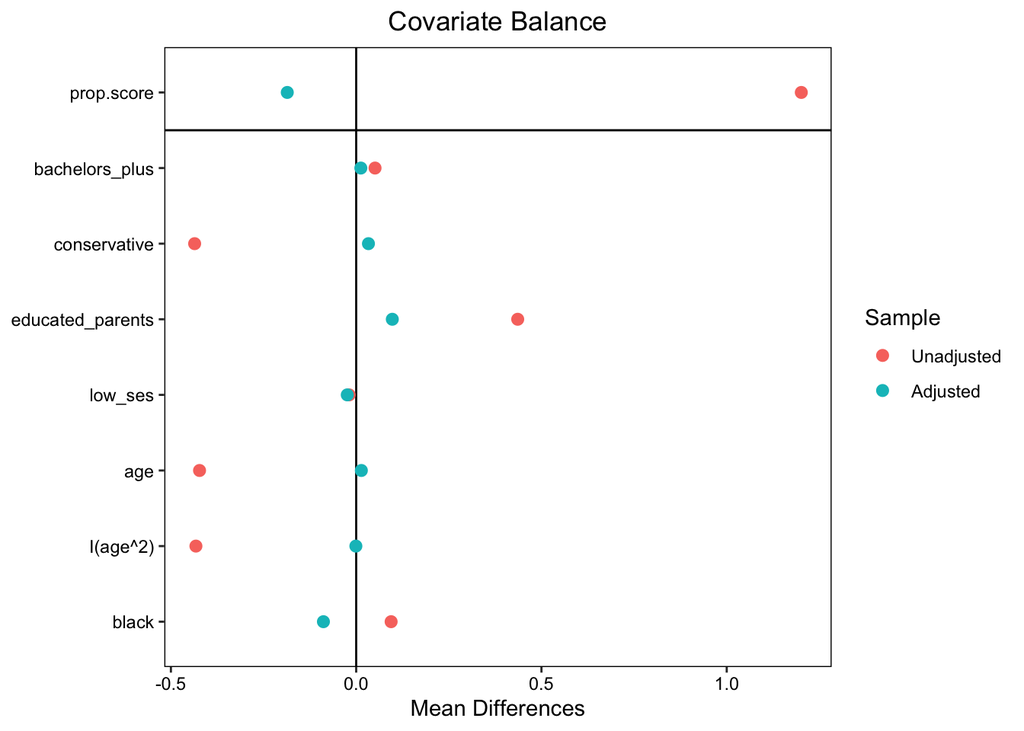

```r
love.plot(W1)
```

Creating a love plot for `W1` showed us that nearly all of our covariates were balanced. The variables with the most “wiggle” appeared to be `educated_parents` (which makes sense, given that that variable was a combination of two different variables and thus more difficult to balance) and `black`.

Now let’s again compare the effect of $T$ on $Y$:

```r
balanced_model <- lm(supports ~ bachelors_plus,  # Do not need to include variables here because
                  data = e,                      ## the variables are included in the weights
                  weights = W1$weights)

tidy(balanced_model, conf.int = TRUE) |>
  filter(term == "bachelors_plus")
```

```
# A tibble: 1 × 7
  term           estimate std.error statistic p.value conf.low conf.high
  <chr>             <dbl>     <dbl>     <dbl>   <dbl>    <dbl>     <dbl>
1 bachelors_plus   0.0257    0.0530     0.485   0.628  -0.0784     0.130
```

### Exercise 9.1.6: Double Robustness

Combining weighting and regression, what is the effect of `T` on `Y`?

```r
double_robustness <- lm(supports ~ bachelors_plus + conservative + educated_parents +
                  low_ses + age + I(age^2) + black,
                  data = e,
                  weights = W1$weights)

tidy(double_robustness, conf.int = TRUE) |>
  filter(term == "bachelors_plus")
```

```
# A tibble: 1 × 7
  term           estimate std.error statistic p.value conf.low conf.high
  <chr>             <dbl>     <dbl>     <dbl>   <dbl>    <dbl>     <dbl>
1 bachelors_plus  0.00434    0.0580    0.0748   0.940   -0.110     0.118
```

After making our model doubly-robust, the effect of $T$ on $Y$ is now 0.004336.

### Exercise 9.1.7: Explanations

Write 3-5 paragraphs explaining your research question, the methods you used, and the answer you came up with.

The research question for this homework assignment was as follows: “Is there a causal relationship between having a college degree (treatment variable) and supporting affirmative action (outcome variable)?” My original hypothesis was that individuals with at least a bachelor’s degree would demonstrate greater support for affirmative action than individuals without a college degree. This hypothesis comes from related literature on how achievement and perceptions of merit impacts support for affirmative action policies (Oyinlade [2013](https://journals.sagepub.com/doi/full/10.1177/2158244013516156), Aberson [2007](https://onlinelibrary.wiley.com/doi/10.1111/j.1559-1816.2007.00266.x)).

The research question included the following variables: The respondent’s personal political ideology (`conservative`), the education levels of the respondent’s parents (as shown in the `educated_parents` variable, which was comprised of respondents’s reports of the highest level of education their mother and father received), whether or not the respondent had a low socioeconomic status (`low_ses`), the age of the respondent (`age`), the age of the respondent squared (using `age^2` to indicate non-linearity of age), the respondent’s race (`black`), and the major that the respondent studied in college (`major1`). In order to better interpret these complex, overlapping variables indicated in the research question, I recoded the majority of them into binary variables (for a further variable breakdown, please see Exercise 9.1.3). Because `major1` was a dumpster fire to recode, it was dropped from the regression models and efforts to balance same.